# Lab 4: Sequential Data

This lab is based on an assignment developed by Prof. Lisa Zhang.

In this assignment, we will build a recurrent neural network to classify a SMS text message as "spam" or "not spam". In the process, you will

1. Clean and process text data for machine learning.
2. Understand and implement a character-level recurrent neural network.
3. Use torchtext to build recurrent neural network models.
4. Understand batching for a recurrent neural network, and use torchtext to implement RNN batching.
5. Understand how transfer learning can be applied to NLP projects.

### What to submit

Submit an HTML file containing all your code, outputs, and write-up from parts A and B. You can produce a HTML file directly from Google Colab. The Colab instructions are provided at the end of this document.

**Do not submit any other files produced by your code.**

Include a link to your colab file in your submission.

Please use Google Colab to complete this assignment. If you want to use Jupyter Notebook, please complete the assignment and upload your Jupyter Notebook file to Google Colab for submission.

## Colab Link

Include a link to your colab file here

Colab Link:  
https://colab.research.google.com/drive/1w9kr5kqPlT0m6Z4AZLz6Vk6pKYopZrTq?usp=sharing

# PART A - Spam Detection [30 pt]

In this part we will construct a LSTM model for identifying spam from non spam messages.

```python
import torch
import torch.nn as nn
import torch.nn.functional as F
import torch.optim as optim
import numpy as np
```

## Part 1. Data Cleaning [10 pt]

We will be using the "SMS Spam Collection Data Set" available at http://archive.ics.uci.edu/ml/datasets/SMS+Spam+Collection

There is a link to download the "Data Folder" at the very top of the webpage. Download the zip file, unzip it, and upload the file `SMSSpamCollection` to Colab.

### Part (a) [1 pt]

Open up the file in Python, and print out one example of a spam SMS, and one example of a non-spam SMS.

What is the label value for a spam message, and what is the label value for a non-spam message?

Answer:  
the label value for a spam message is "spam", and the label value for a non-spam message is "ham".

```python
# print out one example of a spam SMS
print('spam message example:')
for line in open('SMSSpamCollection'):
    if(line.split()[0]=='spam'):
      print(line[5:])
      break
```

```
spam message example:
Free entry in 2 a wkly comp to win FA Cup final tkts 21st May 2005. Text FA to 87121 to receive entry question(std txt rate)T&C's apply 08452810075over18's
```

```python
# print out one example of a non-spam SMS
print('non-spam message example:')
for line in open('SMSSpamCollection'):
    if(line.split()[0]=='ham'):
      print(line[4:])
      break
```

```
non-spam message example:
Go until jurong point, crazy.. Available only in bugis n great world la e buffet... Cine there got amore wat...
```

### Part (b) [1 pt]

How many spam messages are there in the data set? How many non-spam messages are there in the data set?

Answer:  
747 spam messages and 4827 non-spam messages.

```python
# count number of spam messages and number of non-spam messages
spam_cnt = 0
nonspam_cnt = 0
other_cnt = 0

for line in open('SMSSpamCollection'):
    if(line.split()[0]=='spam'):
      spam_cnt += 1
    elif(line.split()[0]=='ham'):
      nonspam_cnt += 1
    else:
      other_cnt += 1

print('number of spam messages:',spam_cnt)
print('number of non-spam messages:',nonspam_cnt)
print('number of wrongly labeled/mislabeled messages:',other_cnt)

# result is consistent to the readme.txt associated with the dataset
```

```
number of spam messages: 747
number of non-spam messages: 4827
number of wrongly labeled/mislabeled messages: 0
```

### Part (c) [2 pt]

We will be using the package `torchtext` to load, process, and batch the data. A tutorial to torchtext is available below. This tutorial uses the same Sentiment140 data set that we explored during lecture.

https://medium.com/@sonicboom8/sentiment-analysis-torchtext-55fb57b1fab8

Unlike what we did during lecture, we will be building a **character level RNN**. That is, we will treat each **character** as a token in our sequence, rather than each **word**.

Identify two advantage and two disadvantage of modelling SMS text messages as a sequence of characters rather than a sequence of words.

Answer:  
advantage:  
1) There are a lot of short forms of spelling (mispelling, custom word). For instance, people use "K" instead of "OK", "n" instead of "and", "wkly" instead of "weekly". There are also some informal words like "lol", "Nah". Overall, the text in SMS text messages is very different from texts from sources of wikipedia, literature, newspapeer. The word embedding tools like GloVe probably cannot recognize a lot of words in SMS text messages and would not work well. Working at a lower level of character is more reasonable. Otherwise, we would need to build our own word embedding model and tune for finding the best dimension, which takes a lot of effort and requires much more data than the size of current dataset.  
2) The number of possible characters is much smaller than the number of distinct words. Moreover, the words in a SMS text are usually short or spelled in short-form. The embedding space required for character level is much more simpler, which indeed allows us to use one-hot encoding while Google Colab can still handle the memory space and computation quite easily.  
disadvantage:  
1) RNN needs to be deeper when using characters, to account for the learning required for recognizing multiple consecutive characters as a word.  
2) there is loss of word structural information when using characters. For example, "i use pen" becomes "i u s e p e n", and we lose information of when a word start and when a word end.

### Part (d) [1 pt]

We will be loading our data set using `torchtext.data.TabularDataset`. The constructor will read directly from the `SMSSpamCollection` file.

For the data file to be read successfuly, we need to specify the **fields** (columns) in the file. In our case, the dataset has two fields:

- a text field containing the sms messages,
- a label field which will be converted into a binary label.

Split the dataset into `train`, `valid`, and `test`. Use a 60-20-20 split. You may find this torchtext API page helpful: https://torchtext.readthedocs.io/en/latest/data.html#dataset

Hint: There is a `Dataset` method that can perform the random split for you.

```python
import torchtext

text_field = torchtext.legacy.data.Field(sequential=True,      # text sequence
                                         tokenize=lambda x: x, # because are building a character-RNN
                                         include_lengths=True, # to track the length of sequences, for batching
                                         batch_first=True,
                                         use_vocab=True)       # to turn each character into an integer index
label_field = torchtext.legacy.data.Field(sequential=False,    # not a sequence
                                   use_vocab=False,     # don't need to track vocabulary
                                   batch_first=True,
                                   preprocessing=lambda x: int(x == 'spam')) # convert text to 0 and 1

fields = [('label', label_field), ('sms', text_field)]
dataset = torchtext.legacy.data.TabularDataset("SMSSpamCollection", # name of the file
                                        "tsv",               # fields are separated by a tab
                                        fields)
# now label of spam message is 1 and label of non-spam message is 0
#dataset[0].sms
#dataset[0].label
train, valid, test = dataset.split(split_ratio=[0.6,0.2,0.2], stratified=False, strata_field='label', random_state=np.random.seed(1517))
```

```python
dataset[0].sms
```

```
'Go until jurong point, crazy.. Available only in bugis n great world la e buffet... Cine there got amore wat...'
```

```python
dataset[0].label
```

```
0
```

### Part (e) [2 pt]

You saw in part (b) that there are many more non-spam messages than spam messages. This **imbalance** in our training data will be problematic for training. We can fix this disparity by duplicating spam messages in the training set, so that the training set is roughly **balanced**.

Explain why having a balanced training set is helpful for training our neural network.

Note: if you are not sure, try removing the below code and train your mode.

Answer:  
When having a balanced training set, the model will focus more on learning the features that truly differ spam messages from non-spam messages, instead of classifying a sample as the major class. For instance, if there are only 1% of the SMS messages are spam, then a model has learnt nothing but simply assigning all mesages as non-spam would have a 99% accuracy. We do not want the model to have preference of one class over the other, but to really identify the difference.

```python
# save the original training examples
old_train_examples = train.examples
# get all the spam messages in `train`
train_spam = []
for item in train.examples:
    if item.label == 1:
        train_spam.append(item)
# duplicate each spam message 6 more times
train.examples = old_train_examples + train_spam * 6
```

### Part (f) [1 pt]

We need to build the vocabulary on the training data by running the below code. This finds all the possible character tokens in the training set.

Explain what the variables `text_field.vocab.stoi` and `text_field.vocab.itos` represent.

Answer:  
text_field.vocab.stoi represents a dictionary mapping a character to an integer value.  
text_filed.vocab.itos represents a dictionary mapping an integer value to a character. (data structure is list, input integer as index, return the value of character)

```python
text_field.build_vocab(train)
#text_field.vocab.stoi
#text_field.vocab.itos
```

### Part (g) [1 pt]

The tokens `<unk>` and `<pad>` were not in our SMS text messages. What do these two values represent?

Answer:  
"unk" is value used to represent rare character that does not fit into the vocabulary.  
"pad" is value used to represent padding, which can be used to adjust length of input sequence. It can ensure that the lengths of input sequences in a batch can be adjusted to be the same.

### Part (h) [1 pt]

Since text sequences are of variable length, `torchtext` provides a `BucketIterator` data loader, which batches similar length sequences together. The iterator also provides functionalities to pad sequences automatically.

Take a look at 10 batches in `train_iter`. What is the maximum length of the input sequence in each batch? How many `<pad>` tokens are used in each of the 10 batches?

```python
train_iter = torchtext.legacy.data.BucketIterator(train,
                                           batch_size=32,
                                           sort_key=lambda x: len(x.sms), # to minimize padding
                                           sort_within_batch=True,        # sort within each batch
                                           repeat=False)                  # repeat the iterator for many epochs
```

```python
# run the previous cell every time rerunning this cell to get consistent result
# because the batch iterator does not reiterate unless reinitialized
# (do not want to iterate through the batches after the first 10)
i = 0 # batch index
for batch in train_iter:
    i+=1
    print(" - Batch "+str(i))
    print('batch shape:',batch.sms[0].shape)
    print('maximum input sequence length:',batch.sms[1].max().item())
    print('number of <pad> tokens used in the batch:',(batch.sms[1].max().item() - batch.sms[1]).sum().item())
    print()
    if i >= 10:
      break
    #print(len(batch))
    #print(batch.sms)
    #print(batch.label)
```

```
 - Batch 1
batch shape: torch.Size([32, 149])
maximum input sequence length: 149
number of <pad> tokens used in the batch: 14

 - Batch 2
batch shape: torch.Size([32, 48])
maximum input sequence length: 48
number of <pad> tokens used in the batch: 31

 - Batch 3
batch shape: torch.Size([32, 152])
maximum input sequence length: 152
number of <pad> tokens used in the batch: 27

 - Batch 4
batch shape: torch.Size([32, 143])
maximum input sequence length: 143
number of <pad> tokens used in the batch: 3

 - Batch 5
batch shape: torch.Size([32, 153])
maximum input sequence length: 153
number of <pad> tokens used in the batch: 31

 - Batch 6
batch shape: torch.Size([32, 70])
maximum input sequence length: 70
number of <pad> tokens used in the batch: 34

 - Batch 7
batch shape: torch.Size([32, 155])
maximum input sequence length: 155
number of <pad> tokens used in the batch: 0

 - Batch 8
batch shape: torch.Size([32, 162])
maximum input sequence length: 162
number of <pad> tokens used in the batch: 22

 - Batch 9
batch shape: torch.Size([32, 142])
maximum input sequence length: 142
number of <pad> tokens used in the batch: 13

 - Batch 10
batch shape: torch.Size([32, 161])
maximum input sequence length: 161
number of <pad> tokens used in the batch: 24
```

Answer:  
See the output of last coding cell above for the maximum length of the input sequence in each batch and number of pad tokens are used in each of the 10 batches

## Part 2. Model Building [5 pt]

Build a recurrent neural network model, using an architecture of your choosing. Use the one-hot embedding of each character as input to your recurrent network. Use one or more fully-connected layers to make the prediction based on your recurrent network output.

Instead of using the RNN output value for the final token, another often used strategy is to max-pool over the entire output array. That is, instead of calling something like:

```
out, _ = self.rnn(x)
self.fc(out[:, -1, :])
```

where `self.rnn` is an `nn.RNN`, `nn.GRU`, or `nn.LSTM` module, and `self.fc` is a fully-connected layer, we use:

```
out, _ = self.rnn(x)
self.fc(torch.max(out, dim=1)[0])
```

This works reasonably in practice. An even better alternative is to concatenate the max-pooling and average-pooling of the RNN outputs:

```
out, _ = self.rnn(x)
out = torch.cat([torch.max(out, dim=1)[0],
                 torch.mean(out, dim=1)], dim=1)
self.fc(out)
```

We encourage you to try out all these options. The way you pool the RNN outputs is one of the "hyperparameters" that you can choose to tune later on.

```python
# You might find this code helpful for obtaining
# PyTorch one-hot vectors.

ident = torch.eye(10)
print(ident[0]) # one-hot vector
print(ident[1]) # one-hot vector
x = torch.tensor([[1, 2], [3, 4]])
print(ident[x]) # one-hot vectors
```

```
tensor([1., 0., 0., 0., 0., 0., 0., 0., 0., 0.])
tensor([0., 1., 0., 0., 0., 0., 0., 0., 0., 0.])
tensor([[[0., 1., 0., 0., 0., 0., 0., 0., 0., 0.],
         [0., 0., 1., 0., 0., 0., 0., 0., 0., 0.]],

        [[0., 0., 0., 1., 0., 0., 0., 0., 0., 0.],
         [0., 0., 0., 0., 1., 0., 0., 0., 0., 0.]]])
```

```python
# number of distinct character, this number would be used as input size of RNN
len(text_field.vocab.itos)
```

```
114
```

```python
class SMSRNN(nn.Module):
    def __init__(self, input_size, hidden_size, num_classes):
        super(SMSRNN, self).__init__()
        self.hidden_size = hidden_size
        self.rnn = nn.GRU(input_size, hidden_size, batch_first=True)
        self.fc = nn.Linear(hidden_size, num_classes)

    def forward(self, x):
        # Set an initial hidden state
        h0 = torch.zeros(1, x.size(0), self.hidden_size)
        # Forward propagate the RNN
        out, _ = self.rnn(x, h0)
        # Pass the output of the last time step to the classifier
        out = self.fc(out[:, -1, :])
        return out
```

Answer:  
I built the network using one layer GRU network followed by a classifier consisting of one linear layer. GRU is a variant of LSTM and also belongs to the class of RNN.

## Part 3. Training [8 pt]

### Part (a) [2 pt]

Complete the `get_accuracy` function, which will compute the accuracy (rate) of your model across a dataset (e.g. validation set). You may modify `torchtext.data.BucketIterator` to make your computation faster.

```python
# modified from prelab 4A
def get_accuracy(model, data):
    """ Compute the accuracy of the `model` across a dataset `data`

    Example usage:

    >>> model = MyRNN() # to be defined
    >>> get_accuracy(model, valid) # the variable `valid` is from above
    """
    correct, total = 0, 0
    indent = torch.eye(114)
    for batch in data:
        texts = batch.sms[0]
        texts = indent[texts]
        labels = batch.label
        output = model(texts)
        pred = output.max(1, keepdim=True)[1]
        correct += pred.eq(labels.view_as(pred)).sum().item()
        total += labels.shape[0]
    return correct / total
```

### Part (b) [2 pt]

Train your model. Plot the training curve of your final model. Your training curve should have the training/validation loss and accuracy plotted periodically.

Note: Not all of your batches will have the same batch size. In particular, if your training set does not divide evenly by your batch size, there will be a batch that is smaller than the rest.

```python
import matplotlib.pyplot as plt
# modified from prelab 4A
def train_rnn_network(model, train, valid, num_epochs=5, learning_rate=1e-5):
    criterion = nn.CrossEntropyLoss()
    optimizer = torch.optim.Adam(model.parameters(), lr=learning_rate)
    losses, train_acc, valid_acc = [], [], []
    epochs = []
    indent = torch.eye(114)
    for epoch in range(num_epochs):
        for batch in train:
            texts = batch.sms[0]
            texts = indent[texts]
            labels = batch.label
            optimizer.zero_grad()
            pred = model(texts)
            loss = criterion(pred, labels)
            loss.backward()
            optimizer.step()
        losses.append(float(loss))

        epochs.append(epoch)
        train_acc.append(get_accuracy(model, train))
        valid_acc.append(get_accuracy(model, valid))
        print("Epoch %d; Loss %f; Train Acc %f; Val Acc %f" % (
              epoch+1, loss, train_acc[-1], valid_acc[-1]))
    # plotting
    plt.title("Training Curve")
    plt.plot(losses, label="Train")
    plt.xlabel("Epoch")
    plt.ylabel("Loss")
    plt.show()

    plt.title("Training Curve")
    plt.plot(epochs, train_acc, label="Train")
    plt.plot(epochs, valid_acc, label="Validation")
    plt.xlabel("Epoch")
    plt.ylabel("Accuracy")
    plt.legend(loc='best')
    plt.show()
```

```python
train_iter = torchtext.legacy.data.BucketIterator(train,
                                           batch_size=32,
                                           sort_key=lambda x: len(x.sms), # to minimize padding
                                           sort_within_batch=False,        # sort within each batch
                                           repeat=False)                  # repeat the iterator for many epochs

valid_iter = torchtext.legacy.data.BucketIterator(valid,
                                           batch_size=32,
                                           sort_key=lambda x: len(x.sms), # to minimize padding
                                           sort_within_batch=False,        # sort within each batch
                                           repeat=False)                  # repeat the iterator for many epochs

test_iter = torchtext.legacy.data.BucketIterator(test,
                                           batch_size=32,
                                           sort_key=lambda x: len(x.sms), # to minimize padding
                                           sort_within_batch=False,        # sort within each batch
                                           repeat=False)                  # repeat the iterator for many epochs
```

### Model 1: default model

```
Epoch 1; Loss 0.681728; Train Acc 0.532596; Val Acc 0.131839
Epoch 2; Loss 0.555486; Train Acc 0.737441; Val Acc 0.802691
Epoch 3; Loss 0.150314; Train Acc 0.924890; Val Acc 0.960538
Epoch 4; Loss 0.165367; Train Acc 0.938872; Val Acc 0.961435
Epoch 5; Loss 0.141713; Train Acc 0.950740; Val Acc 0.943498
Epoch 6; Loss 0.138512; Train Acc 0.947651; Val Acc 0.952466
Epoch 7; Loss 0.381015; Train Acc 0.949439; Val Acc 0.951570
Epoch 8; Loss 0.136932; Train Acc 0.945050; Val Acc 0.956951
Epoch 9; Loss 0.443818; Train Acc 0.951878; Val Acc 0.953363
Epoch 10; Loss 0.211443; Train Acc 0.915786; Val Acc 0.964126
```

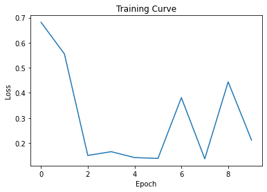

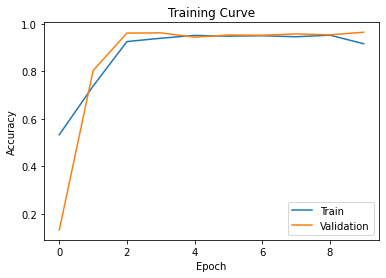

```python
mymodel_1 = SMSRNN(114, 114, 2)

train_rnn_network(mymodel_1, train_iter, valid_iter, num_epochs=10, learning_rate=1e-4)
```

I do not think validation loss is helpful. Plotting training curve is mandatory in this question, and the question asks for plotting train/validation loss and accuracy. So I will make modification to my general training function for presentation of validation loss curve for just this question (in later parts, training curve is not mandatory, so I should be allowed to plot in the way I think is reasonable) See the following code:

```
Epoch 1; Train Loss 0.680654; Train Acc 0.532596; Valid Loss 0.738758; Val Acc 0.131839
Epoch 2; Train Loss 0.550959; Train Acc 0.728174; Valid Loss 0.653033; Val Acc 0.797309
Epoch 3; Train Loss 0.200564; Train Acc 0.891237; Valid Loss 0.161973; Val Acc 0.950673
Epoch 4; Train Loss 0.134633; Train Acc 0.945212; Valid Loss 0.139117; Val Acc 0.952466
Epoch 5; Train Loss 0.198510; Train Acc 0.948626; Valid Loss 0.407024; Val Acc 0.946188
Epoch 6; Train Loss 0.138751; Train Acc 0.949927; Valid Loss 0.139151; Val Acc 0.948879
Epoch 7; Train Loss 0.437609; Train Acc 0.947000; Valid Loss 0.231817; Val Acc 0.952466
Epoch 8; Train Loss 0.202568; Train Acc 0.910584; Valid Loss 0.272912; Val Acc 0.955157
Epoch 9; Train Loss 0.337136; Train Acc 0.951065; Valid Loss 0.254823; Val Acc 0.949776
Epoch 10; Train Loss 0.272261; Train Acc 0.951390; Valid Loss 0.498317; Val Acc 0.944395
```

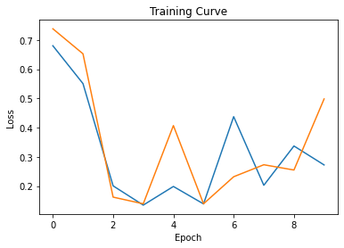

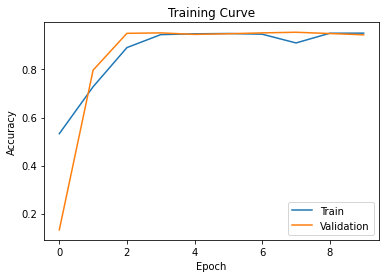

```python
def train_rnn_network_with_valid_loss(model, train, valid, num_epochs=5, learning_rate=1e-5):
    criterion = nn.CrossEntropyLoss()
    optimizer = torch.optim.Adam(model.parameters(), lr=learning_rate)
    losses, train_acc, valid_acc = [], [], []
    valid_losses = []
    epochs = []
    indent = torch.eye(114)
    for epoch in range(num_epochs):
        for batch in train:
            texts = batch.sms[0]
            texts = indent[texts]
            labels = batch.label
            optimizer.zero_grad()
            pred = model(texts)
            loss = criterion(pred, labels)
            loss.backward()
            optimizer.step()
        losses.append(float(loss))
        for batch in valid:
            texts = batch.sms[0]
            texts = indent[texts]
            labels = batch.label
            pred = model(texts)
            valid_loss = criterion(pred, labels)
        valid_losses.append(float(valid_loss))
        epochs.append(epoch)
        train_acc.append(get_accuracy(model, train))
        valid_acc.append(get_accuracy(model, valid))
        print("Epoch %d; Train Loss %f; Train Acc %f; Valid Loss %f; Val Acc %f" % (
              epoch+1, loss, train_acc[-1], valid_loss, valid_acc[-1]))
    # plotting
    plt.title("Training Curve")
    plt.plot(losses, label="Train")
    plt.plot(valid_losses, label="Validation")
    plt.xlabel("Epoch")
    plt.ylabel("Loss")
    plt.show()

    plt.title("Training Curve")
    plt.plot(epochs, train_acc, label="Train")
    plt.plot(epochs, valid_acc, label="Validation")
    plt.xlabel("Epoch")
    plt.ylabel("Accuracy")
    plt.legend(loc='best')
    plt.show()

train_iter = torchtext.legacy.data.BucketIterator(train,
                                           batch_size=32,
                                           sort_key=lambda x: len(x.sms), # to minimize padding
                                           sort_within_batch=False,        # sort within each batch
                                           repeat=False)                  # repeat the iterator for many epochs

valid_iter = torchtext.legacy.data.BucketIterator(valid,
                                           batch_size=32,
                                           sort_key=lambda x: len(x.sms), # to minimize padding
                                           sort_within_batch=False,        # sort within each batch
                                           repeat=False)                  # repeat the iterator for many epochs

test_iter = torchtext.legacy.data.BucketIterator(test,
                                           batch_size=32,
                                           sort_key=lambda x: len(x.sms), # to minimize padding
                                           sort_within_batch=False,        # sort within each batch
                                           repeat=False)                  # repeat the iterator for many epochs

mymodel_validation_loss_plotting = SMSRNN(114, 114, 2)

train_rnn_network_with_valid_loss(mymodel_validation_loss_plotting, train_iter, valid_iter, num_epochs=10, learning_rate=1e-4)
```

### Part (c) [2 pt]

Choose at least 4 hyperparameters to tune. Explain how you tuned the hyperparameters. You don't need to include your training curve for every model you trained. Instead, explain what hyperparemters you tuned, what the best validation accuracy was, and the reasoning behind the hyperparameter decisions you made.

For this assignment, you should tune more than just your learning rate and epoch. Choose at least 2 hyperparameters that are unrelated to the optimizer.

## Important:

There is big difference between trian accuracy and validation accuracy for some models developed. This is due to the fact that we duplicated spam samples for 6 times for training dataset, but not validation dataset (also not test dataset). The significant difference between train accuracy and validation accuracy of a model indicates that the model is not good (it has not developed features well distinguish spam and nonspam messages but just classify sample as the majority class).

### Model 2: tune pooling of RNN outputs

adopt the pooling way of

```
out, _ = self.rnn(x)
out = torch.cat([torch.max(out, dim=1)[0],
                 torch.mean(out, dim=1)], dim=1)
self.fc(out)
```

since it is suggested by the instruction in part (2) Model Building. The result after this modification is getting worse, giving validation accuracy of 27.6%.

```python
class SMSRNN_pooling(nn.Module):
    def __init__(self, input_size, hidden_size, num_classes):
        super(SMSRNN_pooling, self).__init__()
        self.hidden_size = hidden_size
        self.rnn = nn.GRU(input_size, hidden_size, batch_first=True)
        self.fc = nn.Linear(hidden_size*2, num_classes)

    def forward(self, x):
        # Set an initial hidden state
        h0 = torch.zeros(1, x.size(0), self.hidden_size)
        # Forward propagate the RNN
        out, _ = self.rnn(x,h0)
        out = torch.cat([torch.max(out, dim=1)[0],
                         torch.mean(out, dim=1)], dim=1)
        self.fc(out)

        return out
```

```python
train_iter = torchtext.legacy.data.BucketIterator(train,
                                           batch_size=32,
                                           sort_key=lambda x: len(x.sms), # to minimize padding
                                           sort_within_batch=False,        # sort within each batch
                                           repeat=False)                  # repeat the iterator for many epochs

valid_iter = torchtext.legacy.data.BucketIterator(valid,
                                           batch_size=32,
                                           sort_key=lambda x: len(x.sms), # to minimize padding
                                           sort_within_batch=False,        # sort within each batch
                                           repeat=False)                  # repeat the iterator for many epochs

test_iter = torchtext.legacy.data.BucketIterator(test,
                                           batch_size=32,
                                           sort_key=lambda x: len(x.sms), # to minimize padding
                                           sort_within_batch=False,        # sort within each batch
                                           repeat=False)                  # repeat the iterator for many epochs
```

```
Epoch 1; Loss 4.472138; Train Acc 0.546415; Val Acc 0.864574
Epoch 2; Loss 4.188999; Train Acc 0.552268; Val Acc 0.198206
Epoch 3; Loss 4.102985; Train Acc 0.514550; Val Acc 0.401794
Epoch 4; Loss 4.080137; Train Acc 0.523004; Val Acc 0.348879
Epoch 5; Loss 4.065443; Train Acc 0.546903; Val Acc 0.309417
Epoch 6; Loss 4.053336; Train Acc 0.538286; Val Acc 0.293274
Epoch 7; Loss 4.040820; Train Acc 0.560234; Val Acc 0.235874
Epoch 8; Loss 4.027409; Train Acc 0.556332; Val Acc 0.253812
Epoch 9; Loss 4.011721; Train Acc 0.548691; Val Acc 0.256502
Epoch 10; Loss 4.000947; Train Acc 0.563648; Val Acc 0.276233
```

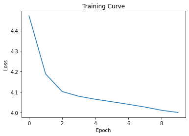

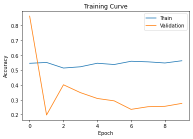

```python
mymodel_2 = SMSRNN_pooling(114, 114, 2)

train_rnn_network(mymodel_2, train_iter, valid_iter, num_epochs=10, learning_rate=1e-4)
```

### Model 3: tune learning rate

The training loss curve is still decreasing at the end for model 2. Let us speed up the training for model 2 by increasing learning rate, to see if going further in the training process can give a better result. The result after this modification is getting better, giving validation accuracy of 72.1% (when train accuracy is also high:65.8%), but still gets beaten by model 1.

```python
train_iter = torchtext.legacy.data.BucketIterator(train,
                                           batch_size=32,
                                           sort_key=lambda x: len(x.sms), # to minimize padding
                                           sort_within_batch=False,        # sort within each batch
                                           repeat=False)                  # repeat the iterator for many epochs

valid_iter = torchtext.legacy.data.BucketIterator(valid,
                                           batch_size=32,
                                           sort_key=lambda x: len(x.sms), # to minimize padding
                                           sort_within_batch=False,        # sort within each batch
                                           repeat=False)                  # repeat the iterator for many epochs

test_iter = torchtext.legacy.data.BucketIterator(test,
                                           batch_size=32,
                                           sort_key=lambda x: len(x.sms), # to minimize padding
                                           sort_within_batch=False,        # sort within each batch
                                           repeat=False)                  # repeat the iterator for many epochs
```

```
Epoch 1; Loss 4.067366; Train Acc 0.517477; Val Acc 0.208072
Epoch 2; Loss 3.996749; Train Acc 0.547391; Val Acc 0.244843
Epoch 3; Loss 3.919111; Train Acc 0.524630; Val Acc 0.382063
Epoch 4; Loss 3.866487; Train Acc 0.571614; Val Acc 0.302242
Epoch 5; Loss 3.783785; Train Acc 0.634368; Val Acc 0.567713
Epoch 6; Loss 3.737473; Train Acc 0.664282; Val Acc 0.637668
Epoch 7; Loss 3.697409; Train Acc 0.655015; Val Acc 0.636771
Epoch 8; Loss 3.656603; Train Acc 0.658430; Val Acc 0.721076
Epoch 9; Loss 3.633656; Train Acc 0.467404; Val Acc 0.868161
Epoch 10; Loss 3.620349; Train Acc 0.467079; Val Acc 0.867265
```

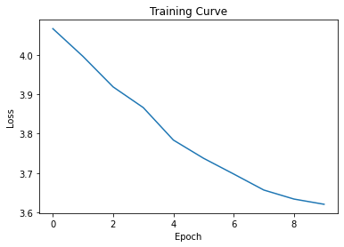

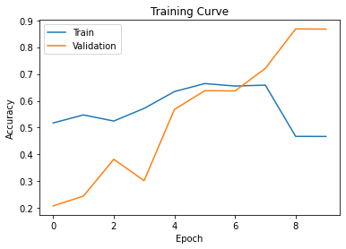

```python
mymodel_3 = SMSRNN_pooling(114, 114, 2)

train_rnn_network(mymodel_3, train_iter, valid_iter, num_epochs=10, learning_rate=5e-4)
```

### Model 4: tune hidden state size

The training curves of model 1 has reached optimum and the difference between training performance and validation performance is very small (validation accuracy is even higher, no overfitting). I would like to increase the size of hidden state of GRU, which is also the input size of the classifier after, in order to increase the complexity of model. Let us see if increasing complexity of model can give more accurate. (usually I want the model to have slight overfit to show that its complexity is enough) The validation accuracy result after this modification is not changing much, giving validation accuracy of 96.3% (close to the original model 1, 96.4%), but training accuracy result has become better (from 91.5% to 95.7%). Remember that the validation set is without class balancing adjustment, we consider model 4 to be better than model 1.

```python
train_iter = torchtext.legacy.data.BucketIterator(train,
                                           batch_size=32,
                                           sort_key=lambda x: len(x.sms), # to minimize padding
                                           sort_within_batch=False,        # sort within each batch
                                           repeat=False)                  # repeat the iterator for many epochs

valid_iter = torchtext.legacy.data.BucketIterator(valid,
                                           batch_size=32,
                                           sort_key=lambda x: len(x.sms), # to minimize padding
                                           sort_within_batch=False,        # sort within each batch
                                           repeat=False)                  # repeat the iterator for many epochs

test_iter = torchtext.legacy.data.BucketIterator(test,
                                           batch_size=32,
                                           sort_key=lambda x: len(x.sms), # to minimize padding
                                           sort_within_batch=False,        # sort within each batch
                                           repeat=False)                  # repeat the iterator for many epochs
```

```
Epoch 1; Loss 0.671555; Train Acc 0.532596; Val Acc 0.131839
Epoch 2; Loss 0.361214; Train Acc 0.833198; Val Acc 0.829596
Epoch 3; Loss 0.137017; Train Acc 0.944237; Val Acc 0.964126
Epoch 4; Loss 0.225640; Train Acc 0.913835; Val Acc 0.961435
Epoch 5; Loss 0.067644; Train Acc 0.953991; Val Acc 0.956054
Epoch 6; Loss 0.145356; Train Acc 0.928304; Val Acc 0.963229
Epoch 7; Loss 0.382173; Train Acc 0.931718; Val Acc 0.965919
Epoch 8; Loss 0.138116; Train Acc 0.917412; Val Acc 0.965022
Epoch 9; Loss 0.313709; Train Acc 0.956430; Val Acc 0.966816
Epoch 10; Loss 0.042463; Train Acc 0.957080; Val Acc 0.963229
```

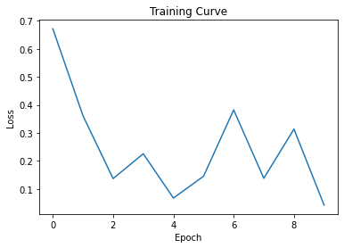

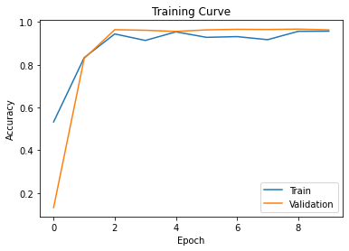

```python
mymodel_4 = SMSRNN(114, 200, 2)

train_rnn_network(mymodel_4, train_iter, valid_iter, num_epochs=10, learning_rate=1e-4)
```

### Model 5: tune batch size

The modification of model 3 from model 2 has improve the model performance. Let us try to improve the performance again by decreasing batch size, to give some volatility and also speed up the training. The result after this modification is getting worse, giving validation accuracy of 13.2%. And there the training accuracy does not show any progression during training.

```python
train_iter = torchtext.legacy.data.BucketIterator(train,
                                           batch_size=16,
                                           sort_key=lambda x: len(x.sms), # to minimize padding
                                           sort_within_batch=False,        # sort within each batch
                                           repeat=False)                  # repeat the iterator for many epochs

valid_iter = torchtext.legacy.data.BucketIterator(valid,
                                           batch_size=16,
                                           sort_key=lambda x: len(x.sms), # to minimize padding
                                           sort_within_batch=False,        # sort within each batch
                                           repeat=False)                  # repeat the iterator for many epochs

test_iter = torchtext.legacy.data.BucketIterator(test,
                                           batch_size=16,
                                           sort_key=lambda x: len(x.sms), # to minimize padding
                                           sort_within_batch=False,        # sort within each batch
                                           repeat=False)                  # repeat the iterator for many epochs
```

```
Epoch 1; Loss 4.193885; Train Acc 0.532596; Val Acc 0.131839
Epoch 2; Loss 4.081707; Train Acc 0.532596; Val Acc 0.131839
Epoch 3; Loss 4.050034; Train Acc 0.532596; Val Acc 0.131839
Epoch 4; Loss 4.022778; Train Acc 0.532596; Val Acc 0.131839
Epoch 5; Loss 3.999580; Train Acc 0.532596; Val Acc 0.131839
Epoch 6; Loss 3.969063; Train Acc 0.532596; Val Acc 0.131839
Epoch 7; Loss 3.927299; Train Acc 0.532596; Val Acc 0.131839
Epoch 8; Loss 3.897198; Train Acc 0.532596; Val Acc 0.131839
Epoch 9; Loss 3.857147; Train Acc 0.532596; Val Acc 0.131839
Epoch 10; Loss 3.835732; Train Acc 0.532596; Val Acc 0.131839
Epoch 11; Loss 3.812955; Train Acc 0.532596; Val Acc 0.131839
Epoch 12; Loss 3.782296; Train Acc 0.532596; Val Acc 0.131839
Epoch 13; Loss 3.752553; Train Acc 0.532596; Val Acc 0.131839
Epoch 14; Loss 3.727608; Train Acc 0.547716; Val Acc 0.152466
Epoch 15; Loss 3.702667; Train Acc 0.532596; Val Acc 0.131839
Epoch 16; Loss 3.697327; Train Acc 0.532596; Val Acc 0.131839
Epoch 17; Loss 3.666888; Train Acc 0.544302; Val Acc 0.146188
Epoch 18; Loss 3.652070; Train Acc 0.532596; Val Acc 0.131839
Epoch 19; Loss 3.635770; Train Acc 0.570639; Val Acc 0.191928
Epoch 20; Loss 3.636589; Train Acc 0.532596; Val Acc 0.131839
```

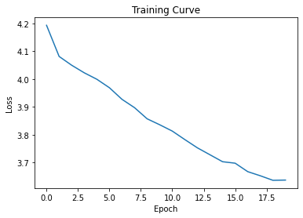

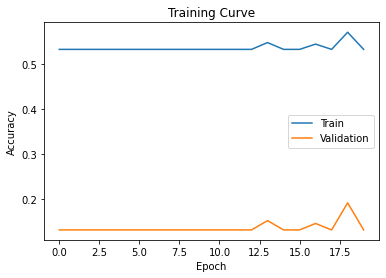

```python
mymodel_5 = SMSRNN_pooling(114, 114, 2)

train_rnn_network(mymodel_5, train_iter, valid_iter, num_epochs=20, learning_rate=1e-4)
```

### Model 6: tuning drop out

Model 4 has great performance. Let us add drop out to the output of GRU network (which is also the input of classifier followed) to introduce some randomness, which can help make the features more robust. The result after this modification is getting worse, giving validation accuracy of 95.5% (before the sudden drop of last epoch).

```python
class SMSRNN_dropout(nn.Module):
    def __init__(self, input_size, hidden_size, num_classes):
        super(SMSRNN_dropout, self).__init__()
        self.hidden_size = hidden_size
        self.rnn = nn.GRU(input_size, hidden_size, batch_first=True)
        self.fc = nn.Linear(hidden_size, num_classes)
        self.dropout = nn.Dropout(0.1)

    def forward(self, x):
        # Set an initial hidden state
        h0 = torch.zeros(1, x.size(0), self.hidden_size)
        # Forward propagate the RNN
        out, _ = self.rnn(x, h0)
        # Pass the output of the last time step to the classifier
        out = self.fc(self.dropout(out[:, -1, :]))

        return out
```

```python
train_iter = torchtext.legacy.data.BucketIterator(train,
                                           batch_size=32,
                                           sort_key=lambda x: len(x.sms), # to minimize padding
                                           sort_within_batch=False,        # sort within each batch
                                           repeat=False)                  # repeat the iterator for many epochs

valid_iter = torchtext.legacy.data.BucketIterator(valid,
                                           batch_size=32,
                                           sort_key=lambda x: len(x.sms), # to minimize padding
                                           sort_within_batch=False,        # sort within each batch
                                           repeat=False)                  # repeat the iterator for many epochs

test_iter = torchtext.legacy.data.BucketIterator(test,
                                           batch_size=32,
                                           sort_key=lambda x: len(x.sms), # to minimize padding
                                           sort_within_batch=False,        # sort within each batch
                                           repeat=False)                  # repeat the iterator for many epochs
```

```
Epoch 1; Loss 0.680702; Train Acc 0.532596; Val Acc 0.131839
Epoch 2; Loss 0.551304; Train Acc 0.731751; Val Acc 0.815247
Epoch 3; Loss 0.079453; Train Acc 0.938709; Val Acc 0.920179
Epoch 4; Loss 0.110523; Train Acc 0.911722; Val Acc 0.853812
Epoch 5; Loss 0.343422; Train Acc 0.908795; Val Acc 0.955157
Epoch 6; Loss 0.203847; Train Acc 0.911722; Val Acc 0.955157
Epoch 7; Loss 0.381318; Train Acc 0.954154; Val Acc 0.949776
Epoch 8; Loss 0.321759; Train Acc 0.728337; Val Acc 0.928251
Epoch 9; Loss 0.406373; Train Acc 0.955129; Val Acc 0.955157
Epoch 10; Loss 0.691786; Train Acc 0.542513; Val Acc 0.356054
```

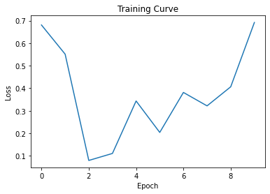

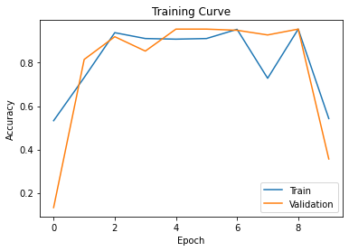

```python
mymodel_6 = SMSRNN_dropout(114, 200, 2)

train_rnn_network(mymodel_6, train_iter, valid_iter, num_epochs=10, learning_rate=1e-4)
```

The best validation accuracy of all model tested was 96.4%. The validation accuracy of the model selected is 96.3% due to its better training accuracy.

### Part (d) [1 pt]

Before we deploy a machine learning model, we usually want to have a better understanding of how our model performs beyond its validation accuracy. An important metric to track is *how well our model performs in certain subsets of the data*.

In particular, what is the model's error rate amongst data with negative labels? This is called the **false positive rate**.

What about the model's error rate amongst data with positive labels? This is called the **false negative rate**.

Report your final model's false positive and false negative rate across the validation set.

```python
# Create a Dataset of only spam validation examples
valid_spam = torchtext.legacy.data.Dataset(
    [e for e in valid.examples if e.label == 1],
    valid.fields)

# compute error rate among data with positive labels
valid_iter = torchtext.legacy.data.BucketIterator(valid_spam,
                                           batch_size=32,
                                           sort_key=lambda x: len(x.sms), # to minimize padding
                                           sort_within_batch=False,        # sort within each batch
                                           repeat=False)                  # repeat the iterator for many epochs
print('false negative rate:',(1-get_accuracy(mymodel_4, valid_iter)))

# Create a Dataset of only non-spam validation examples
valid_nospam = torchtext.legacy.data.Dataset(
    [e for e in valid.examples if e.label == 0],
    valid.fields)

# compute error rate among data with zero labels
valid_iter = torchtext.legacy.data.BucketIterator(valid_nospam,
                                           batch_size=32,
                                           sort_key=lambda x: len(x.sms), # to minimize padding
                                           sort_within_batch=False,        # sort within each batch
                                           repeat=False)                  # repeat the iterator for many epochs
print('false positive rate:',(1-get_accuracy(mymodel_4, valid_iter)))
```

```
false negative rate: 0.03401360544217691
false positive rate: 0.04132231404958675
```

Answer:  
false positive rate across the validation set: 4.1%  
false negative rate across the validation set: 3.4%

### Part (e) [1 pt]

The impact of a false positive vs a false negative can be drastically different. If our spam detection algorithm was deployed on your phone, what is the impact of a false positive on the phone's user? What is the impact of a false negative?

## Part 4. Evaluation [7 pt]

### Part (a) [1 pt]

Report the final test accuracy of your model.

```python
# compute test accuracy
test_iter = torchtext.legacy.data.BucketIterator(test,
                                           batch_size=32,
                                           sort_key=lambda x: len(x.sms), # to minimize padding
                                           sort_within_batch=False,        # sort within each batch
                                           repeat=False)                  # repeat the iterator for many epochs
print('test accuracy:',(get_accuracy(mymodel_4, test_iter)))
```

```
test accuracy: 0.9587073608617595
```

Answer:  
final test accuracy: 95.9%

### Part (b) [1 pt]

Report the false positive rate and false negative rate of your model across the test set.

```python
# Create a Dataset of only spam test examples
test_spam = torchtext.legacy.data.Dataset(
    [e for e in test.examples if e.label == 1],
    test.fields)

# compute error rate among data with positive labels
test_iter = torchtext.legacy.data.BucketIterator(test_spam,
                                           batch_size=32,
                                           sort_key=lambda x: len(x.sms), # to minimize padding
                                           sort_within_batch=False,        # sort within each batch
                                           repeat=False)                  # repeat the iterator for many epochs
print('false negative rate:',(1-get_accuracy(mymodel_4, test_iter)))

# Create a Dataset of only non-spam test examples
test_nospam = torchtext.legacy.data.Dataset(
    [e for e in test.examples if e.label == 0],
    test.fields)

# compute error rate among data with negative labels
test_iter = torchtext.legacy.data.BucketIterator(test_nospam,
                                           batch_size=32,
                                           sort_key=lambda x: len(x.sms), # to minimize padding
                                           sort_within_batch=False,        # sort within each batch
                                           repeat=False)                  # repeat the iterator for many epochs
print('false positive rate:',(1-get_accuracy(mymodel_4, test_iter)))
```

```
false negative rate: 0.05303030303030298
false positive rate: 0.04073319755600813
```

### Part (c) [3 pt]

What is your model's prediction of the **probability** that the SMS message "machine learning is sooo cool!" is spam?

Hint: To begin, use `text_field.vocab.stoi` to look up the index of each character in the vocabulary.

```python
msg = "machine learning is sooo cool!"
encoded_msg = torch.zeros((1,len(msg)))
indent = torch.eye(114)
for i in range(len(msg)):
  encoded_msg[0,i] = text_field.vocab.stoi[msg[i]]

output_prob = F.softmax(mymodel_4(indent[encoded_msg.long()]))
print('probability that the SMS message is spam is:',output_prob[0,1].item())
```

```
probability that the SMS message is spam is: 0.429569810628891
```

Answer:  
probability that the SMS message is spam: 43.0%

### Part (d) [2 pt]

Do you think detecting spam is an easy or difficult task?

Since machine learning models are expensive to train and deploy, it is very important to compare our models against baseline models: a simple model that is easy to build and inexpensive to run that we can compare our recurrent neural network model against.

Explain how you might build a simple baseline model. This baseline model can be a simple neural network (with very few weights), a hand-written algorithm, or any other strategy that is easy to build and test.

**Do not actually build a baseline model. Instead, provide instructions on how to build it.**

Answer:  
I think detecting spam is a difficult task. I usually know (or can expect) when someone might send message to me (e.g. when I am about to hang out with my friends). But our model can only make judgement based on the text, without other information about the user. This is difficult.  
simple baseline model:  
SMS messages are expected to be short. Some longer ones that contain some formation information usually does not contain special character (characters other than number, letter, comma, period, colon). A simple base line model can be a decision tree of depth 2 or 3 that takes the length of message (character length) and count of special characters in message as input and classify whether the message is spam or non-spam.

# PART B - Transfer Learning [20 pt]

In this part we will compare our earlier model with one that takes advantage of a generative RNN model to improve the prediction. There are several ways to implement transfer learning with RNNs, here we will use an approach known as ULMFiT developed by fastai. Rather than rebuilding the model from scratch, we will take advantage of the fastai library.

Provided below is some helper code to get you started.

#### Helper Code

```python
# install relevant libraries
!pip install fastai
```

```python
# load relevant libraries
from fastai import *
import pandas as pd
import numpy as np
from functools import partial
import io
import os
from fastai.text import *
```

```python
# download SPAM data
!wget https://archive.ics.uci.edu/ml/machine-learning-databases/00228/smsspamcollection.zip
!unzip smsspamcollection.zip
```

```
--2022-03-23 10:56:03--  https://archive.ics.uci.edu/ml/machine-learning-databases/00228/smsspamcollection.zip
Resolving archive.ics.uci.edu (archive.ics.uci.edu)... 128.195.10.252
Connecting to archive.ics.uci.edu (archive.ics.uci.edu)|128.195.10.252|:443... connected.
HTTP request sent, awaiting response... 200 OK
Length: 203415 (199K) [application/x-httpd-php]
Saving to: ‘smsspamcollection.zip’

smsspamcollection.z 100%[===================>] 198.65K   383KB/s    in 0.5s

2022-03-23 10:56:04 (383 KB/s) - ‘smsspamcollection.zip’ saved [203415/203415]

Archive:  smsspamcollection.zip
replace SMSSpamCollection? [y]es, [n]o, [A]ll, [N]one, [r]ename: y
  inflating: SMSSpamCollection
  inflating: readme
```

This time we will load the data using pandas.

```python
# set up data and verify
df1 = pd.read_csv('SMSSpamCollection', sep='\t',  header=None, names=['target', 'text'])
df1.head()
```

|  | target | text |
| --- | --- | --- |
| 0 | ham | Go until jurong point, crazy.. Available only ... |
| 1 | ham | Ok lar... Joking wif u oni... |
| 2 | spam | Free entry in 2 a wkly comp to win FA Cup fina... |
| 3 | ham | U dun say so early hor... U c already then say... |
| 4 | ham | Nah I don't think he goes to usf, he lives aro... |

```python
# check distribution
df1['target'].value_counts()
```

```
ham     4825
spam     747
Name: target, dtype: int64
```

## Important:

The code above checking distribution label shows that there are only 4825 non-spam images, which should be 4827. The df1.head() output suggests that the data transforming should be correct mostly. Probably it is because of the pandas read_csv function, that misses the splitting for two non-spam messages. This should not affect the later result much, so I will leave it as it is. Note that all the above codes in part B are given, not written by me. I have posted a discussion on Piazza about this,  
https://piazza.com/class/ky7jmkckbm83wv?cid=240

Split the data into training and validation datasets.

```python
# split the data and check dimensions

from sklearn.model_selection import train_test_split

# split data into training and validation set
df_trn, df_val = train_test_split(df1, stratify = df1['target'], test_size = 0.3, random_state = 999)
```

```python
df_trn.shape, df_val.shape
```

```
((3900, 2), (1672, 2))
```

There has been output left for the line of code above (before me doing any coding), which matches the output when I rerun the helper code above, suggesting a total size of 5572, which should be 5574. Confirm that this difference of 2 non-spam messages is not due to my coding. I do not think I am expected to modify the helper code, so just leave it as it is.

### Create the language model

Esentially, the language model contains the structure of the language (English in this case), allowing us to quickly use in a classification model, skipping the part of learning the semantics of the language from scratch.

Creating a language model from scratch can be intensive due to the sheer size of data. Instead we will download the pre-trained model, which is a neural network (NN) with an AWD_LSTM architecture. By setting pretrained = True we say to fastai to download the weights from the trained model (a corpus of 103 MM of wikipedia articles).

```python
# create pretrained language model data
data_lm = TextLMDataBunch.from_df(train_df = df_trn, valid_df = df_val, path = "")
lang_mod = language_model_learner(data_lm,  arch = AWD_LSTM, pretrained = True, drop_mult=1.)
```

```
Downloading https://s3.amazonaws.com/fast-ai-modelzoo/wt103-fwd.tgz
```

### Testing the language model

```python
for i in range(5):
  print(lang_mod.predict("Recent research has shown that", n_words=10))
```

```
Recent research has shown that Ipod Use have a 50 % " quick
Recent research has shown that Rofl accounts for over 20 % of Internet
Recent research has shown that a British drug player would be able to pull
Recent research has shown that Kinda 's post on rock record did not work
Recent research has shown that M. Jay Goes had poor information regarding
```

Each time we excecute the `predict`, we get a different random sentence, completed with the number of choosen words (`n_words`).

Try your own sentences!

### Fine-tuning the language model

The language model that we have "loaded" is great for generating wikipedia-like sentances, but here we're more interested in generating data like our email dataset.

Make sure to enable GPU for this step or it make takes several hours to train.

```python
# fine-tune language model data
lang_mod.fit_one_cycle(4, max_lr= 5e-02)
lang_mod.freeze_to(-1)
lang_mod.fit_one_cycle(3, slice(1e-2/(2.6**4), 1e-2))
lang_mod.freeze_to(-2)
lang_mod.fit_one_cycle(3, slice(3e-3/(2.6**4), 1e-3))
lang_mod.unfreeze()
lang_mod.fit_one_cycle(3, slice(3e-3/(2.6**4), 1e-3))

# save language model
lang_mod.save_encoder('my_awsome_encoder')
```

| epoch | train_loss | valid_loss | accuracy | time |
| --- | --- | --- | --- | --- |
| 0 | 5.582020 | 3.874200 | 0.285714 | 00:01 |
| 1 | 4.847179 | 3.786281 | 0.314286 | 00:01 |
| 2 | 4.390517 | 3.830021 | 0.314286 | 00:01 |
| 3 | 4.062455 | 3.726872 | 0.314286 | 00:01 |

| epoch | train_loss | valid_loss | accuracy | time |
| --- | --- | --- | --- | --- |
| 0 | 3.597220 | 3.719516 | 0.314286 | 00:01 |
| 1 | 3.559773 | 3.683261 | 0.285714 | 00:01 |
| 2 | 3.497475 | 3.661067 | 0.285714 | 00:01 |

| epoch | train_loss | valid_loss | accuracy | time |
| --- | --- | --- | --- | --- |
| 0 | 3.422514 | 3.687206 | 0.285714 | 00:01 |
| 1 | 3.394608 | 3.671416 | 0.271429 | 00:01 |
| 2 | 3.369165 | 3.670289 | 0.271429 | 00:01 |

| epoch | train_loss | valid_loss | accuracy | time |
| --- | --- | --- | --- | --- |
| 0 | 3.335625 | 3.669102 | 0.285714 | 00:02 |
| 1 | 3.295554 | 3.642756 | 0.271429 | 00:02 |
| 2 | 3.262264 | 3.660516 | 0.271429 | 00:02 |

### Classification model

Now we can train a classification model that will identify spam and non-spam messages. Since we used a fastai language model, it will be easier to just continue working with the fastai library.

```python
# Classifier model data
data_clas = TextClasDataBunch.from_df(path = "", train_df = df_trn,  valid_df = df_val, vocab=data_lm.train_ds.vocab, bs=32)
```

```python
data_clas.show_batch()
```

| text | target |
| --- | --- |
| xxbos xxmaj the last thing i ever wanted to do was hurt you . xxmaj and i did n't think it would have . xxmaj you 'd laugh , be embarassed , delete the xxunk and keep going . xxmaj but as far as i kne… | ham |
| xxbos xxmaj sad story of a xxmaj man - xxmaj last week was my b'day . xxmaj my xxmaj wife did'nt wish me . xxmaj my xxmaj parents forgot n so did my xxmaj kids . i went to work . xxmaj even my xxmaj c… | ham |
| xxbos xxmaj how to xxmaj make a girl xxmaj happy ? xxmaj it 's not at all difficult to make girls happy . u only need to be ... 1 . a friend 2 . xxmaj xxunk 3 . xxmaj lover 4 . xxmaj xxunk . . . < # >… | ham |
| xxbos xxmaj storming msg : xxmaj wen u lift d phne , u say " xxup hello " xxmaj do u knw wt is d real meaning of xxup hello ? ? . . . xxmaj it 's d name of a girl .. ! . . . xxmaj yes .. xxmaj and u k… | ham |
| xxbos xxmaj hey sweet , i was wondering when you had a moment if you might come to me ? i want to send a file to someone but it wo n't go over yahoo for them because their connection sucks , remember … | ham |

```python
# create the classifier
learn_classifier = text_classifier_learner(data_clas, drop_mult=0.7, arch = AWD_LSTM)
```

```python
# load language model
learn_classifier.load_encoder('my_awsome_encoder')
```

[output not shown]

[output cut: 34 more lines]

[output not shown]

0.00% [0/1 00:00<00:00]

| epoch | train_loss | valid_loss | accuracy | time |
| --- | --- | --- | --- | --- |

73.55% [89/121 00:01<00:00 1.0650]

```
LR Finder is complete, type {learner_name}.recorder.plot() to see the graph.
Min numerical gradient: 6.31E-07
Min loss divided by 10: 3.63E-02
```

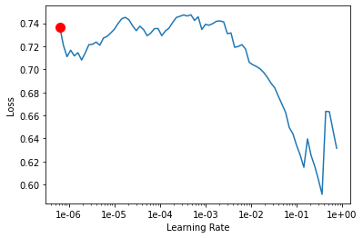

```python
# train classifier
learn_classifier.lr_find()
learn_classifier.recorder.plot(suggestion=True)
```

```python
learn_classifier.fit_one_cycle(5, max_lr=1e-2, moms=(0.8,0.7))
```

| epoch | train_loss | valid_loss | accuracy | time |
| --- | --- | --- | --- | --- |
| 0 | 0.412861 | 0.087453 | 0.984450 | 00:02 |
| 1 | 0.177754 | 0.071465 | 0.983254 | 00:03 |
| 2 | 0.141667 | 0.059695 | 0.985048 | 00:03 |
| 3 | 0.086812 | 0.064718 | 0.983852 | 00:03 |
| 4 | 0.082528 | 0.081035 | 0.982656 | 00:03 |

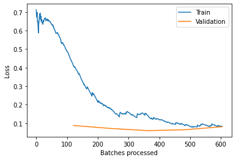

```python
learn_classifier.recorder.plot_losses()
```

0.00% [0/1 00:00<00:00]

| epoch | train_loss | valid_loss | accuracy | time |
| --- | --- | --- | --- | --- |

61.98% [75/121 00:01<00:00 0.1302]

```
LR Finder is complete, type {learner_name}.recorder.plot() to see the graph.
Min numerical gradient: 1.32E-06
Min loss divided by 10: 3.31E-07
```

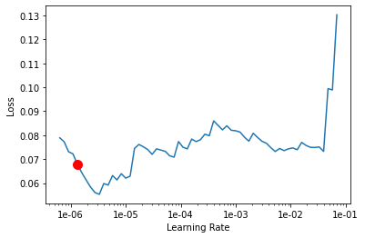

```python
lang_mod.freeze_to(-1)

learn_classifier.lr_find()
learn_classifier.recorder.plot(suggestion=True)
```

Test out the classification model on spam and non-spam examples.

```python
# predict
learn_classifier.predict('did you buy the groceries for dinner? :)')
```

```
(Category tensor(0), tensor(0), tensor([1.0000e+00, 2.0466e-08]))
```

```python
# predict
learn_classifier.predict('Free entry call back now')
```

```
(Category tensor(1), tensor(1), tensor([0.3709, 0.6291]))
```

Next we will evaluate on all of our validation data.

```python
# get predictions from validation
valid_preds, valid_label=learn_classifier.get_preds(ds_type=DatasetType.Valid, ordered=True)
valid_preds.shape
```

```
torch.Size([1672, 2])
```

## Part 1. Evaluate Performance [10pt]

### Part (a) [5pt]

Implement the above helper code for spam detection.

What is the accuracy obtained with ULMFiT? How does ULMFiT compare to the approach in the first part using only LSTM?

```python
valid_preds_class = valid_preds.max(1, keepdim=True)[1]
correct = valid_preds_class.eq(valid_label.view_as(valid_preds_class)).sum().item()
total = valid_preds.shape[0]
print('validation accuracy with ULMFiT:',correct/total)
```

```
validation accuracy with ULMFiT: 0.9826555023923444
```

Answer:  
Validation accuracy obtained with ULMFiT is 98.3%, which is higher than part A model 96.3% validation accuracy. ULMFiT model gives better validation accuracy compared to the approach in the first part using only LSTM (GRU is a variant of LSTM)

### Part (b) [5pt]

Provide a confusion matrix of the performance for the two models. How do they compare? Are there any qualitative differences between the performances (i.e. examine the samples for which the models differred)?

Answer:  
The following confusion matrix is in form of:  
[[TP, FN]  
[FP, TN]]

- part A model  
  confusion matrix:  
  [[142, 5]  
  [ 40, 928]]]  
  false negative rate: 3.4%  
  false positive rate: 4.1%
- part B model  
  confusion matrix:  
  [[196, 28]  
  [ 1, 1447]]]  
  false negative rate: 12.5%  
  false positive rate: 0.069%

Part A model has lower false negative rate, and part B model has lower false positive rate. Meaning that part A model is more aggresive on classifying samples as spam than part B model. This is reasonable, because we duplicate spam samples 6 times when training part A model. </font>

```python
# confusion matrix for model from part A
# confusion matrix in shape of [[TP,FN],[FP,TN]]
# compute error rate among data with positive labels
valid_iter = torchtext.legacy.data.BucketIterator(valid_spam,
                                           batch_size=32,
                                           sort_key=lambda x: len(x.sms), # to minimize padding
                                           sort_within_batch=False,        # sort within each batch
                                           repeat=False)                  # repeat the iterator for many epochs

# compute TP, FN
correct, total = 0, 0
indent = torch.eye(114)
for batch in valid_iter:
    texts = batch.sms[0]
    texts = indent[texts]
    labels = batch.label
    output = mymodel_4(texts)
    pred = output.max(1, keepdim=True)[1]
    correct += pred.eq(labels.view_as(pred)).sum().item()
    total += labels.shape[0]

parta_TP = correct
parta_FN = total - correct

# compute error rate among data with zero labels
valid_iter = torchtext.legacy.data.BucketIterator(valid_nospam,
                                           batch_size=32,
                                           sort_key=lambda x: len(x.sms), # to minimize padding
                                           sort_within_batch=False,        # sort within each batch
                                           repeat=False)                  # repeat the iterator for many epochs

# compute TP, FN
correct, total = 0, 0
indent = torch.eye(114)
for batch in valid_iter:
    texts = batch.sms[0]
    texts = indent[texts]
    labels = batch.label
    output = mymodel_4(texts)
    pred = output.max(1, keepdim=True)[1]
    correct += pred.eq(labels.view_as(pred)).sum().item()
    total += labels.shape[0]

parta_TN = correct
parta_FP = total - correct

# assembly confusion matrix for part A GRU network
parta_conf_matrix = np.zeros((2,2))
parta_conf_matrix[0,0] = parta_TP
parta_conf_matrix[0,1] = parta_FN
parta_conf_matrix[1,0] = parta_FP
parta_conf_matrix[1,1] = parta_TN
print(parta_conf_matrix.astype(int))
print('false negative rate:',1-(parta_conf_matrix[0,0]/(parta_conf_matrix[0,0]+parta_conf_matrix[0,1])))
print('false positive rate:',1-(parta_conf_matrix[1,1]/(parta_conf_matrix[1,0]+parta_conf_matrix[1,1])))
```

```
[[142   5]
 [ 40 928]]
false negative rate: 0.03401360544217691
false positive rate: 0.04132231404958675
```

```python
# confusion matrix for model from part B

partb_conf_matrix = np.zeros((2,2))
for i in range(valid_label.shape[0]):
  if valid_label[i]:
    if valid_preds_class[i]:
      partb_conf_matrix[0,0] += 1 # TP
    else:
      partb_conf_matrix[0,1] += 1 # FN
  else:
    if valid_preds_class[i]:
      partb_conf_matrix[1,0] += 1 # FP
    else:
      partb_conf_matrix[1,1] += 1 # TN
print(partb_conf_matrix.astype(int))
print('false negative rate:',1-(partb_conf_matrix[0,0]/(partb_conf_matrix[0,0]+partb_conf_matrix[0,1])))
print('false positive rate:',1-(partb_conf_matrix[1,1]/(partb_conf_matrix[1,0]+partb_conf_matrix[1,1])))
```

```
[[ 196   28]
 [   1 1447]]
false negative rate: 0.125
false positive rate: 0.0006906077348066697
```

## Part 2. Evaluate on New Data [10pt]

### Part (a) [4pt]

What is your model's prediction of the probability that the SMS message "machine learning is sooo cool!" is spam?

```python
# model from part A
msg = "machine learning is sooo cool!"
encoded_msg = torch.zeros((1,len(msg)))
indent = torch.eye(114)
for i in range(len(msg)):
  encoded_msg[0,i] = text_field.vocab.stoi[msg[i]]

output_prob = F.softmax(mymodel_4(indent[encoded_msg.long()]),dim=1)
print('probability that the SMS message is spam is:',output_prob[0,1].item())
```

```
probability that the SMS message is spam is: 0.429569810628891
```

```python
# model from part B
print('probability that the SMS message is spam is:',learn_classifier.predict('machine learning is sooo cool!')[2][1].item())
```

```
probability that the SMS message is spam is: 6.113198055407443e-14
```

Answer:  
SMS message: "machine learning is sooo cool!"  
part A model gives probability that the SMS message is spam of 43.0%  
part B model gives probability that the SMS message is spam of 6.11e-12% (can be treated as 0%)

### Part (b) [3 pt]

Load 5 sample sentences from your spam mail and test it out out the two models you created. How well do they perform?

Answer:  
part A model successfully classify 4 of the 5 spam mails as spam.  
part B model successfully classify 3 of the 5 spam mails as spam.  
The spam probability of part A model is higher for all 5 texts. I would say that part A model is good at finding the actual spam mails as spam mails, and part B model is a bit passive on classifying samples as spam mails.

```python
# spam message 1 (Cell Phone text message)
# compute part A model spam probability
msg_spam_1 = 'You received an e-Transfer. Reply (info) for more details'
msg = msg_spam_1
encoded_msg = torch.zeros((1,len(msg)))
indent = torch.eye(114)
for i in range(len(msg)):
  encoded_msg[0,i] = text_field.vocab.stoi[msg[i]]

output_prob = F.softmax(mymodel_4(indent[encoded_msg.long()]),dim=1)
print('part A model spam probability:',output_prob[0,1].item())

# compute part B model spam probability
print('part B model spam probability:',learn_classifier.predict(msg)[2][1].item())
```

```
part A model spam probability: 0.5748657584190369
part B model spam probability: 0.5572317242622375
```

```python
# spam message 2 (Cell Phone text message)
# compute part A model spam probability
msg_spam_2 = 'Your deposit is ready type d for more details'
msg = msg_spam_2
encoded_msg = torch.zeros((1,len(msg)))
indent = torch.eye(114)
for i in range(len(msg)):
  encoded_msg[0,i] = text_field.vocab.stoi[msg[i]]

output_prob = F.softmax(mymodel_4(indent[encoded_msg.long()]),dim=1)
print('part A model spam probability:',output_prob[0,1].item())

# compute part B model spam probability
print('part B model spam probability:',learn_classifier.predict(msg)[2][1].item())
```

```
part A model spam probability: 0.3916044235229492
part B model spam probability: 0.0003049151855520904
```

```python
# spam message 3 (E-mail)
msg_spam_3 = '''Level up your startup in our annual summer program, Hatchery NEST!

Develop your business model, minimum viable product, and pitching skills from May to August under the guidance of your dedicated Advisory Board.

With over 100 startups launched since 2012, will you be next?

Applications are due January 31, 2022. Don't delay, APPLY TODAY.


Additional Entrepreneurship Resources

Tuesdays, 12PM - Weekly Speaker Series - Startup CEOs share their story and insights
Tuesdays, 3+4PM - Weekly Idea Markets - A casual setting to share ideas, explore business development, and meet cofounders
Connect with us: https://linktr.ee/uofthatchery

Kaisa Moran
Operations Lead
The Entrepreneurship Hatchery
Faculty of Applied Science and Engineering
University of Toronto
uoft.me/hatchery
'''
msg = msg_spam_3
encoded_msg = torch.zeros((1,len(msg)))
indent = torch.eye(114)
for i in range(len(msg)):
  encoded_msg[0,i] = text_field.vocab.stoi[msg[i]]

output_prob = F.softmax(mymodel_4(indent[encoded_msg.long()]),dim=1)
print('part A model spam probability:',output_prob[0,1].item())

# compute part B model spam probability
print('part B model spam probability:',learn_classifier.predict(msg)[2][1].item())
```

```
part A model spam probability: 0.9873033165931702
part B model spam probability: 0.6572480201721191
```

```python
# spam message 4 (Cell Phone text message)
# compute part A model spam probability
msg_spam_4 = '''Hello, do you need a part-time job?
Monthly salary of Canadian dollars *6000-15000*,
At least *200* Canadian dollars per dat.
No service charge.
Work is easy and can be done at home.
If you are interested in this job,
please contact
WhatsApp:+14245028045'''


msg = msg_spam_4
encoded_msg = torch.zeros((1,len(msg)))
indent = torch.eye(114)
for i in range(len(msg)):
  encoded_msg[0,i] = text_field.vocab.stoi[msg[i]]

output_prob = F.softmax(mymodel_4(indent[encoded_msg.long()]),dim=1)
print('part A model spam probability:',output_prob[0,1].item())

# compute part B model spam probability
print('part B model spam probability:',learn_classifier.predict(msg)[2][1].item())
```

```
part A model spam probability: 0.988493025302887
part B model spam probability: 0.3848876357078552
```

```python
# spam message 5 (Cell Phone text message)
# compute part A model spam probability
msg_spam_5 = '''Free Scotia-infoAlert:

This is for 16476480391

Your card access has been locked.
See this link:

http://190.115.21.75

id# SC10582'''
msg = msg_spam_5
encoded_msg = torch.zeros((1,len(msg)))
indent = torch.eye(114)
for i in range(len(msg)):
  encoded_msg[0,i] = text_field.vocab.stoi[msg[i]]

output_prob = F.softmax(mymodel_4(indent[encoded_msg.long()]),dim=1)
print('part A model spam probability:',output_prob[0,1].item())

# compute part B model spam probability
print('part B model spam probability:',learn_classifier.predict(msg)[2][1].item())
```

```
part A model spam probability: 0.9866958856582642
part B model spam probability: 0.7017882466316223
```

### Part (c) [3pt]

Load 5 sample sentences from your regular mail and test it out out the two models you created. How well do they perform?

```python
# non-spam message 1 (Cell Phone text message)
msg_nospam_1 = 'Your Fido verification code is: 3129'
msg = msg_nospam_1
encoded_msg = torch.zeros((1,len(msg)))
indent = torch.eye(114)
for i in range(len(msg)):
  encoded_msg[0,i] = text_field.vocab.stoi[msg[i]]

output_prob = F.softmax(mymodel_4(indent[encoded_msg.long()]),dim=1)
print('part A model spam probability:',output_prob[0,1].item())

# compute part B model spam probability
print('part B model spam probability:',learn_classifier.predict(msg)[2][1].item())
```

```
part A model spam probability: 0.6477575898170471
part B model spam probability: 0.025838831439614296
```

```python
# non-spam message 2 (Cell Phone text message)
msg_nospam_2 = 'Sorry just saw your message'
msg = msg_nospam_2
encoded_msg = torch.zeros((1,len(msg)))
indent = torch.eye(114)
for i in range(len(msg)):
  encoded_msg[0,i] = text_field.vocab.stoi[msg[i]]

output_prob = F.softmax(mymodel_4(indent[encoded_msg.long()]),dim=1)
print('part A model spam probability:',output_prob[0,1].item())

# compute part B model spam probability
print('part B model spam probability:',learn_classifier.predict(msg)[2][1].item())
```

```
part A model spam probability: 0.4003402888774872
part B model spam probability: 1.1843840795264238e-13
```

```python
# non-spam message 3 (E-mail)
msg_nospam_3 = '''Dear Graduating Students,



If you have completed a FASE technical emphasis (or PsychEng Specialization) and will have completed all your degree requirements by end of April 2022 please fill out the Technical Emphasis request form here to have your requirements reviewed.



The deadline to fill this in is by May 1.



You will be notified once the emphasis has been processed and will appear on your transcript (approx. by end of May).



Please note - once processed, the emphasis appears ONLY on your transcript, not on your degree.



Best,





David Duong | Engineering Graduate Affairs Officer

Office of the Dean
Faculty of Applied Science and Engineering | University of Toronto
44 St. George Street | Toronto | Ontario | M5S 2E4
d.duong@utoronto.ca | www.engineering.utoronto.ca

Tel 416.978.1713 | Fax 416.946.0371
'''
msg = msg_nospam_3
encoded_msg = torch.zeros((1,len(msg)))
indent = torch.eye(114)
for i in range(len(msg)):
  encoded_msg[0,i] = text_field.vocab.stoi[msg[i]]

output_prob = F.softmax(mymodel_4(indent[encoded_msg.long()]),dim=1)
print('part A model spam probability:',output_prob[0,1].item())

# compute part B model spam probability
print('part B model spam probability:',learn_classifier.predict(msg)[2][1].item())
```

```
part A model spam probability: 0.9901893734931946
part B model spam probability: 0.29306790232658386
```

```python
# non-spam message 4 (Cell Phone text message)
# compute part A model spam probability
msg_nospam_4 = 'Okay. Omg what is that'
msg = msg_nospam_4
encoded_msg = torch.zeros((1,len(msg)))
indent = torch.eye(114)
for i in range(len(msg)):
  encoded_msg[0,i] = text_field.vocab.stoi[msg[i]]

output_prob = F.softmax(mymodel_4(indent[encoded_msg.long()]),dim=1)
print('part A model spam probability:',output_prob[0,1].item())

# compute part B model spam probability
print('part B model spam probability:',learn_classifier.predict(msg)[2][1].item())
```

```
part A model spam probability: 0.3383679687976837
part B model spam probability: 2.5420734378720118e-14
```

```python
# non-spam message 5 (Cell Phone text message)
# compute part A model spam probability
msg_nospam_5 = '''Important! Your appointment on 2nd February 2022 at 12:00 PM EST with Dr. Dai is coming up in about 3 hours.  For more details about your upcoming appointment, please visit: inputhealth.page.link/k4yhP'''
msg = msg_nospam_5
encoded_msg = torch.zeros((1,len(msg)))
indent = torch.eye(114)
for i in range(len(msg)):
  encoded_msg[0,i] = text_field.vocab.stoi[msg[i]]

output_prob = F.softmax(mymodel_4(indent[encoded_msg.long()]),dim=1)
print('part A model spam probability:',output_prob[0,1].item())

# compute part B model spam probability
print('part B model spam probability:',learn_classifier.predict(msg)[2][1].item())
```

```
part A model spam probability: 0.9850542545318604
part B model spam probability: 0.7920661568641663
```

### Saving to HTML

Detailed instructions for saving to HTML can be found [here](https://stackoverflow.com/questions/53460051/convert-ipynb-notebook-to-html-in-google-colab/64487858#64487858). Provided below are a summary of the instructions:

(1) download your ipynb file by clicking on File->Download.ipynb

(2) reupload your file to the temporary Google Colab storage (you can access the temporary storage from the tab to the left)

(3) run the following:

```python
%%shell
jupyter nbconvert --to html LAB_4_Sequential_Data.ipynb
```

[output not shown]

(4) the html file will be available for download in the temporary Google Colab storage

(5) review the html file and make sure all the results are visible before submitting your assignment to Quercus